# Heart Failure Prediction with Logistic vs KNN model

Data set is taken from http://archive.ics.uci.edu/ml/datasets/Heart+failure+clinical+records.

Exploratory Analysis

```r
heart<-read.csv("heart_failure_clinical_records_dataset.csv")
head(heart)
```

|  | age | anaemia | creatinine_phosphokinase | diabetes | ejection_fraction | high_blood_pressure | platelets | serum_creatinine | serum_sodium | sex | smoking | time | DEATH_EVENT |
| --- | --- | --- | --- | --- | --- | --- | --- | --- | --- | --- | --- | --- | --- |
| 1 | 75 | 0 | 582 | 0 | 20 | 1 | 265000 | 1.9 | 130 | 1 | 0 | 4 | 1 |
| 2 | 55 | 0 | 7861 | 0 | 38 | 0 | 263358 | 1.1 | 136 | 1 | 0 | 6 | 1 |
| 3 | 65 | 0 | 146 | 0 | 20 | 0 | 162000 | 1.3 | 129 | 1 | 1 | 7 | 1 |
| 4 | 50 | 1 | 111 | 0 | 20 | 0 | 210000 | 1.9 | 137 | 1 | 0 | 7 | 1 |
| 5 | 65 | 1 | 160 | 1 | 20 | 0 | 327000 | 2.7 | 116 | 0 | 0 | 8 | 1 |
| 6 | 90 | 1 | 47 | 0 | 40 | 1 | 204000 | 2.1 | 132 | 1 | 1 | 8 | 1 |

```r
str(heart)
```

```
## 'data.frame':    299 obs. of  13 variables:
##  $ age                     : num  75 55 65 50 65 90 75 60 65 80 ...
##  $ anaemia                 : int  0 0 0 1 1 1 1 1 0 1 ...
##  $ creatinine_phosphokinase: int  582 7861 146 111 160 47 246 315 157 123 ...
##  $ diabetes                : int  0 0 0 0 1 0 0 1 0 0 ...
##  $ ejection_fraction       : int  20 38 20 20 20 40 15 60 65 35 ...
##  $ high_blood_pressure     : int  1 0 0 0 0 1 0 0 0 1 ...
##  $ platelets               : num  265000 263358 162000 210000 327000 ...
##  $ serum_creatinine        : num  1.9 1.1 1.3 1.9 2.7 2.1 1.2 1.1 1.5 9.4 ...
##  $ serum_sodium            : int  130 136 129 137 116 132 137 131 138 133 ...
##  $ sex                     : int  1 1 1 1 0 1 1 1 0 1 ...
##  $ smoking                 : int  0 0 1 0 0 1 0 1 0 1 ...
##  $ time                    : int  4 6 7 7 8 8 10 10 10 10 ...
##  $ DEATH_EVENT             : int  1 1 1 1 1 1 1 1 1 1 ...
```

```r
any(is.na(heart))
```

```
## [1] FALSE
```

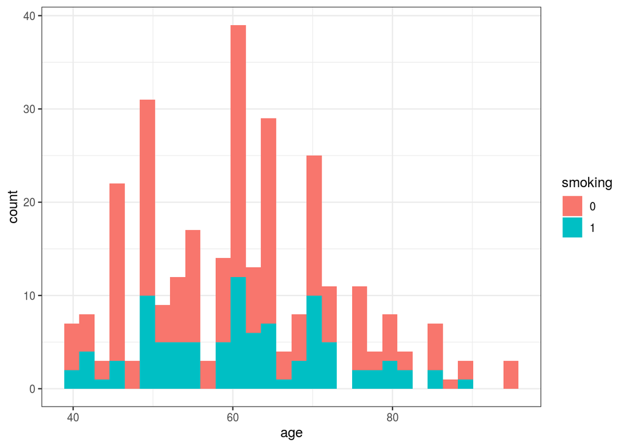

```r
heart$sex<-factor(heart$sex)
heart$DEATH_EVENT<-factor(heart$DEATH_EVENT)
heart$smoking<-factor(heart$smoking)
heart$high_blood_pressure<-factor(heart$high_blood_pressure)
heart$diabetes<-factor(heart$diabetes)
heart$anaemia<-factor(heart$anaemia)
attach(heart)
library(ggplot2)
ggplot(heart, aes(age))+geom_histogram(aes(fill=smoking), bins=30)+theme_bw()
```

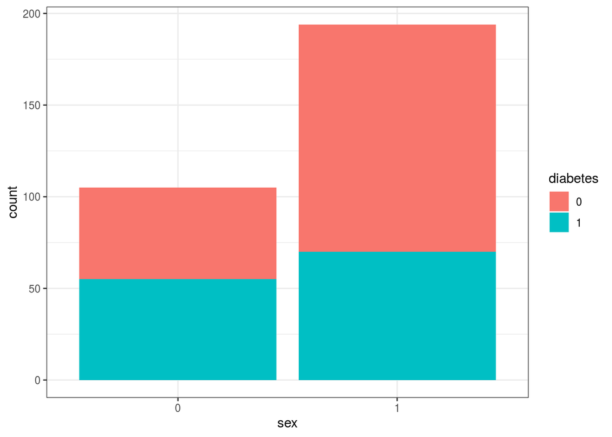

```r
ggplot(heart, aes(sex))+geom_bar(aes(fill=diabetes), bins=30)+theme_bw()
```

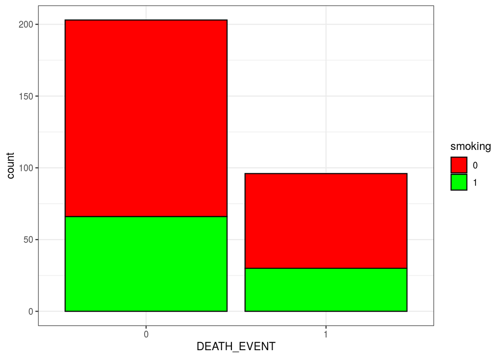

```r
ggplot(heart, aes(DEATH_EVENT))+geom_bar(aes(fill=smoking),color='black')+
  scale_fill_manual( values = c('1'="green", '0'='red'))+theme_bw()
```

Random 70/30 Data Set Split

```r
set.seed(101)
library(caTools)
index<-sample.split(heart$DEATH_EVENT, SplitRatio = 0.7)
heart.train<-heart[index, ]
heart.test<-subset(heart,index==F)
str(heart.train)
```

```
## 'data.frame':    209 obs. of  13 variables:
##  $ age                     : num  75 55 65 50 65 90 75 60 65 80 ...
##  $ anaemia                 : Factor w/ 2 levels "0","1": 1 1 1 2 2 2 2 2 1 2 ...
##  $ creatinine_phosphokinase: int  582 7861 146 111 160 47 246 315 157 123 ...
##  $ diabetes                : Factor w/ 2 levels "0","1": 1 1 1 1 2 1 1 2 1 1 ...
##  $ ejection_fraction       : int  20 38 20 20 20 40 15 60 65 35 ...
##  $ high_blood_pressure     : Factor w/ 2 levels "0","1": 2 1 1 1 1 2 1 1 1 2 ...
##  $ platelets               : num  265000 263358 162000 210000 327000 ...
##  $ serum_creatinine        : num  1.9 1.1 1.3 1.9 2.7 2.1 1.2 1.1 1.5 9.4 ...
##  $ serum_sodium            : int  130 136 129 137 116 132 137 131 138 133 ...
##  $ sex                     : Factor w/ 2 levels "0","1": 2 2 2 2 1 2 2 2 1 2 ...
##  $ smoking                 : Factor w/ 2 levels "0","1": 1 1 2 1 1 2 1 2 1 2 ...
##  $ time                    : int  4 6 7 7 8 8 10 10 10 10 ...
##  $ DEATH_EVENT             : Factor w/ 2 levels "0","1": 2 2 2 2 2 2 2 2 2 2 ...
```

```r
str(heart.test)
```

```
## 'data.frame':    90 obs. of  13 variables:
##  $ age                     : num  75 50 45 75 70 58 70 70 50 80 ...
##  $ anaemia                 : Factor w/ 2 levels "0","1": 2 2 1 1 1 2 1 1 1 2 ...
##  $ creatinine_phosphokinase: int  81 168 582 582 122 60 582 571 582 553 ...
##  $ diabetes                : Factor w/ 2 levels "0","1": 1 1 1 2 2 1 1 2 2 1 ...
##  $ ejection_fraction       : int  38 38 14 30 45 38 20 45 38 20 ...
##  $ high_blood_pressure     : Factor w/ 2 levels "0","1": 2 2 1 2 2 1 2 2 1 2 ...
##  $ platelets               : num  368000 276000 166000 263358 284000 ...
##  $ serum_creatinine        : num  4 1.1 0.8 1.83 1.3 5.8 1.83 1.2 1.9 4.4 ...
##  $ serum_sodium            : int  131 137 127 134 136 134 134 139 135 133 ...
##  $ sex                     : Factor w/ 2 levels "0","1": 2 2 2 1 2 2 2 2 2 2 ...
##  $ smoking                 : Factor w/ 2 levels "0","1": 2 1 1 1 2 1 2 2 2 1 ...
##  $ time                    : int  10 11 14 23 26 26 31 33 35 41 ...
##  $ DEATH_EVENT             : Factor w/ 2 levels "0","1": 2 2 2 2 2 2 2 2 2 2 ...
```

Logistic model

Step function helped to determine significant variables to simplify the model with smallest AIC: 167.54.

```r
glm.mod.heart<- glm (DEATH_EVENT ~ . , family=binomial('logit'), heart.train)
summary(glm.mod.heart)
```

```
##
## Call:
## glm(formula = DEATH_EVENT ~ ., family = binomial("logit"), data = heart.train)
##
## Deviance Residuals:
##     Min       1Q   Median       3Q      Max
## -2.2847  -0.5374  -0.2449   0.4767   2.2627
##
## Coefficients:
##                            Estimate Std. Error z value Pr(>|z|)
## (Intercept)               1.005e+01  7.393e+00   1.360 0.173918
## age                       4.478e-02  1.829e-02   2.448 0.014358 *
## anaemia1                  4.097e-02  4.309e-01   0.095 0.924249
## creatinine_phosphokinase  1.985e-04  1.951e-04   1.018 0.308894
## diabetes1                 9.059e-02  4.273e-01   0.212 0.832116
## ejection_fraction        -6.712e-02  1.891e-02  -3.550 0.000386 ***
## high_blood_pressure1     -4.841e-01  4.357e-01  -1.111 0.266590
## platelets                -5.492e-07  2.082e-06  -0.264 0.791985
## serum_creatinine          6.368e-01  2.068e-01   3.079 0.002076 **
## serum_sodium             -6.580e-02  5.191e-02  -1.268 0.204901
## sex1                     -4.277e-01  4.953e-01  -0.864 0.387832
## smoking1                 -3.702e-01  5.111e-01  -0.724 0.468864
## time                     -2.213e-02  3.528e-03  -6.273 3.54e-10 ***
## ---
## Signif. codes:  0 '***' 0.001 '**' 0.01 '*' 0.05 '.' 0.1 ' ' 1
##
## (Dispersion parameter for binomial family taken to be 1)
##
##     Null deviance: 262.21  on 208  degrees of freedom
## Residual deviance: 151.99  on 196  degrees of freedom
## AIC: 177.99
##
## Number of Fisher Scoring iterations: 6
```

```r
step(glm.mod.heart)##checking for the best AIC
```

```
## Start:  AIC=177.99
## DEATH_EVENT ~ age + anaemia + creatinine_phosphokinase + diabetes +
##     ejection_fraction + high_blood_pressure + platelets + serum_creatinine +
##     serum_sodium + sex + smoking + time
##
##                            Df Deviance    AIC
## - anaemia                   1   152.00 176.00
## - diabetes                  1   152.04 176.04
## - platelets                 1   152.06 176.06
## - smoking                   1   152.52 176.52
## - sex                       1   152.74 176.74
## - creatinine_phosphokinase  1   153.13 177.13
## - high_blood_pressure       1   153.25 177.25
## - serum_sodium              1   153.65 177.65
## <none>                          151.99 177.99
## - age                       1   158.49 182.49
## - serum_creatinine          1   161.73 185.73
## - ejection_fraction         1   167.15 191.15
## - time                      1   214.99 238.99
##
## Step:  AIC=176
## DEATH_EVENT ~ age + creatinine_phosphokinase + diabetes + ejection_fraction +
##     high_blood_pressure + platelets + serum_creatinine + serum_sodium +
##     sex + smoking + time
##
##                            Df Deviance    AIC
## - diabetes                  1   152.05 174.05
## - platelets                 1   152.07 174.07
## - smoking                   1   152.54 174.54
## - sex                       1   152.78 174.78
## - creatinine_phosphokinase  1   153.14 175.14
## - high_blood_pressure       1   153.28 175.28
## - serum_sodium              1   153.66 175.66
## <none>                          152.00 176.00
## - age                       1   158.51 180.51
## - serum_creatinine          1   161.74 183.74
## - ejection_fraction         1   167.26 189.26
## - time                      1   217.33 239.33
##
## Step:  AIC=174.05
```

[output cut: 83 more lines]

```
## <none>                   156.24 168.24
## - age                1   161.30 171.30
## - serum_creatinine   1   168.97 178.97
## - ejection_fraction  1   170.05 180.05
## - time               1   221.74 231.74
##
## Step:  AIC=167.54
## DEATH_EVENT ~ age + ejection_fraction + serum_creatinine + time
##
##                     Df Deviance    AIC
## <none>                   157.54 167.54
## - age                1   162.76 170.76
## - serum_creatinine   1   171.33 179.33
## - ejection_fraction  1   171.33 179.33
## - time               1   222.47 230.47
```

```
##
## Call:  glm(formula = DEATH_EVENT ~ age + ejection_fraction + serum_creatinine +
##     time, family = binomial("logit"), data = heart.train)
##
## Coefficients:
##       (Intercept)                age  ejection_fraction   serum_creatinine
##           0.55675            0.03782           -0.06091            0.69112
##              time
##          -0.02139
##
## Degrees of Freedom: 208 Total (i.e. Null);  204 Residual
## Null Deviance:       262.2
## Residual Deviance: 157.5     AIC: 167.5
```

```r
glm.mod.heart2<- glm (DEATH_EVENT ~ age+ejection_fraction+ serum_creatinine+time , family=binomial('logit'), heart.train)
summary(glm.mod.heart2)
```

```
##
## Call:
## glm(formula = DEATH_EVENT ~ age + ejection_fraction + serum_creatinine +
##     time, family = binomial("logit"), data = heart.train)
##
## Deviance Residuals:
##     Min       1Q   Median       3Q      Max
## -2.0833  -0.5765  -0.2469   0.4917   2.3525
##
## Coefficients:
##                    Estimate Std. Error z value Pr(>|z|)
## (Intercept)        0.556750   1.230795   0.452 0.651017
## age                0.037823   0.017116   2.210 0.027119 *
## ejection_fraction -0.060911   0.017678  -3.446 0.000570 ***
## serum_creatinine   0.691120   0.193163   3.578 0.000346 ***
## time              -0.021386   0.003348  -6.388 1.68e-10 ***
## ---
## Signif. codes:  0 '***' 0.001 '**' 0.01 '*' 0.05 '.' 0.1 ' ' 1
##
## (Dispersion parameter for binomial family taken to be 1)
##
##     Null deviance: 262.21  on 208  degrees of freedom
## Residual deviance: 157.54  on 204  degrees of freedom
## AIC: 167.54
##
## Number of Fisher Scoring iterations: 5
```

Prediction

Model performed with 84% accuracy.

```r
fitted.prob<-predict(glm.mod.heart2, heart.test, type='response')
fitted.results<-ifelse(fitted.prob > 0.5, 1, 0)
misclass.error<- mean(fitted.results != heart.test$DEATH_EVENT)##Error
1-misclass.error## accuracy
```

```
## [1] 0.8444444
```

Confusion matrix

Type 1 error is rejection of class ‘O’ when it is true. Type 2 error is fail to reject of class “1” when it is true.

In this instance, with death example, a higher incidence of false positives is the worst possible outcome. So it would be best for the model when precision is higher then recall metrics, since cost of failing to predict the death event of ‘0’ is higher.

```r
table( fitted.prob > 0.5,heart.test$DEATH_EVENT)
```

```
##
##          0  1
##   FALSE 55  8
##   TRUE   6 21
```

```r
###Accuracy
(55+21)/(55+21+6+8)#all correct / all
```

```
## [1] 0.8444444
```

```r
###Recall
55/(55+6)##within the level category - true positives / all actual positives
```

```
## [1] 0.9016393
```

```r
##Precision - True Positives / Predicted Positives
55/(55+8)## within the False Column
```

```
## [1] 0.8730159
```

KNN modeling

Standardize the data set

```r
heart$sex<-as.numeric(heart$sex)
heart$DEATH_EVENT<-as.numeric(heart$DEATH_EVENT)
heart$smoking<-as.numeric(heart$smoking)
heart$high_blood_pressure<-as.numeric(heart$high_blood_pressure)
heart$diabetes<-as.numeric(heart$diabetes)
heart$anaemia<-as.numeric(heart$anaemia)
str(heart)
```

```
## 'data.frame':    299 obs. of  13 variables:
##  $ age                     : num  75 55 65 50 65 90 75 60 65 80 ...
##  $ anaemia                 : num  1 1 1 2 2 2 2 2 1 2 ...
##  $ creatinine_phosphokinase: int  582 7861 146 111 160 47 246 315 157 123 ...
##  $ diabetes                : num  1 1 1 1 2 1 1 2 1 1 ...
##  $ ejection_fraction       : int  20 38 20 20 20 40 15 60 65 35 ...
##  $ high_blood_pressure     : num  2 1 1 1 1 2 1 1 1 2 ...
##  $ platelets               : num  265000 263358 162000 210000 327000 ...
##  $ serum_creatinine        : num  1.9 1.1 1.3 1.9 2.7 2.1 1.2 1.1 1.5 9.4 ...
##  $ serum_sodium            : int  130 136 129 137 116 132 137 131 138 133 ...
##  $ sex                     : num  2 2 2 2 1 2 2 2 1 2 ...
##  $ smoking                 : num  1 1 2 1 1 2 1 2 1 2 ...
##  $ time                    : int  4 6 7 7 8 8 10 10 10 10 ...
##  $ DEATH_EVENT             : num  2 2 2 2 2 2 2 2 2 2 ...
```

```r
heart.st<-scale(heart[1:12])
head(heart.st)
```

```
##             age    anaemia creatinine_phosphokinase   diabetes
## [1,]  1.1909487 -0.8696469              0.000165451 -0.8461608
## [2,] -0.4904571 -0.8696469              7.502062717 -0.8461608
## [3,]  0.3502458 -0.8696469             -0.449185725 -0.8461608
## [4,] -0.9108085  1.1460462             -0.485257493 -0.8461608
## [5,]  0.3502458  1.1460462             -0.434757017  1.1778559
## [6,]  2.4520030  1.1460462             -0.551217299 -0.8461608
##      ejection_fraction high_blood_pressure     platelets serum_creatinine
## [1,]      -1.527997920           1.3569966  1.678834e-02       0.48923681
## [2,]      -0.007064906          -0.7344569  7.523048e-09      -0.28407611
## [3,]      -1.527997920          -0.7344569 -1.036336e+00      -0.09074788
## [4,]      -1.527997920          -0.7344569 -5.455595e-01       0.48923681
## [5,]      -1.527997920          -0.7344569  6.507077e-01       1.26254973
## [6,]       0.161927651           1.3569966 -6.069065e-01       0.68256504
##      serum_sodium        sex   smoking      time
## [1,]  -1.50151891  0.7344569 -0.686531 -1.626775
## [2,]  -0.14173853  0.7344569 -0.686531 -1.601007
## [3,]  -1.72814897  0.7344569  1.451727 -1.588122
## [4,]   0.08489153  0.7344569 -0.686531 -1.588122
## [5,]  -4.67433977 -1.3569966 -0.686531 -1.575238
## [6,]  -1.04825878  0.7344569  1.451727 -1.575238
```

Random Split of a Data Set

```r
set.seed(101)
library(caTools)
index<-sample.split(heart$DEATH_EVENT, SplitRatio = 0.7)
heart.train2<-heart[index, ]
heart.test2<-subset(heart,index==F)
str(heart.train2)
```

```
## 'data.frame':    209 obs. of  13 variables:
##  $ age                     : num  75 55 65 50 65 90 75 60 65 80 ...
##  $ anaemia                 : num  1 1 1 2 2 2 2 2 1 2 ...
##  $ creatinine_phosphokinase: int  582 7861 146 111 160 47 246 315 157 123 ...
##  $ diabetes                : num  1 1 1 1 2 1 1 2 1 1 ...
##  $ ejection_fraction       : int  20 38 20 20 20 40 15 60 65 35 ...
##  $ high_blood_pressure     : num  2 1 1 1 1 2 1 1 1 2 ...
##  $ platelets               : num  265000 263358 162000 210000 327000 ...
##  $ serum_creatinine        : num  1.9 1.1 1.3 1.9 2.7 2.1 1.2 1.1 1.5 9.4 ...
##  $ serum_sodium            : int  130 136 129 137 116 132 137 131 138 133 ...
##  $ sex                     : num  2 2 2 2 1 2 2 2 1 2 ...
##  $ smoking                 : num  1 1 2 1 1 2 1 2 1 2 ...
##  $ time                    : int  4 6 7 7 8 8 10 10 10 10 ...
##  $ DEATH_EVENT             : num  2 2 2 2 2 2 2 2 2 2 ...
```

```r
str(heart.test2)
```

```
## 'data.frame':    90 obs. of  13 variables:
##  $ age                     : num  75 50 45 75 70 58 70 70 50 80 ...
##  $ anaemia                 : num  2 2 1 1 1 2 1 1 1 2 ...
##  $ creatinine_phosphokinase: int  81 168 582 582 122 60 582 571 582 553 ...
##  $ diabetes                : num  1 1 1 2 2 1 1 2 2 1 ...
##  $ ejection_fraction       : int  38 38 14 30 45 38 20 45 38 20 ...
##  $ high_blood_pressure     : num  2 2 1 2 2 1 2 2 1 2 ...
##  $ platelets               : num  368000 276000 166000 263358 284000 ...
##  $ serum_creatinine        : num  4 1.1 0.8 1.83 1.3 5.8 1.83 1.2 1.9 4.4 ...
##  $ serum_sodium            : int  131 137 127 134 136 134 134 139 135 133 ...
##  $ sex                     : num  2 2 2 1 2 2 2 2 2 2 ...
##  $ smoking                 : num  2 1 1 1 2 1 2 2 2 1 ...
##  $ time                    : int  10 11 14 23 26 26 31 33 35 41 ...
##  $ DEATH_EVENT             : num  2 2 2 2 2 2 2 2 2 2 ...
```

KNN modeling

Minimum classification error is 0.32, when k =8 which is still higher then in logistic model.

```r
library(class)
set.seed(101)
knn.mod.heart<- knn(heart.train2[1:12], heart.test2[1:12], heart.train2$DEATH_EVENT, k=1)
errow.knn.heart<-mean(knn.mod.heart == heart.test2$DEATH_EVENT)

knn.mod.heart<- NULL
error.knn.heart<- NULL
for (i in 1:20){
  set.seed(101)
  knn.mod.heart<- knn(heart.train2[,1:12], heart.test2[,1:12], heart.train2$DEATH_EVENT, k=i)
  error.knn.heart[i]<-mean(knn.mod.heart != heart.test2$DEATH_EVENT)
}
error.knn.heart
```

```
##  [1] 0.4555556 0.4777778 0.3888889 0.3555556 0.4000000 0.3888889 0.3777778
##  [8] 0.3222222 0.3555556 0.3333333 0.3444444 0.3222222 0.3333333 0.3333333
## [15] 0.3222222 0.3222222 0.3333333 0.3222222 0.3222222 0.3444444
```

Visualizing K value with Elbow method

K = 8 gives the best classification output, however it is not as good as logistic model output.

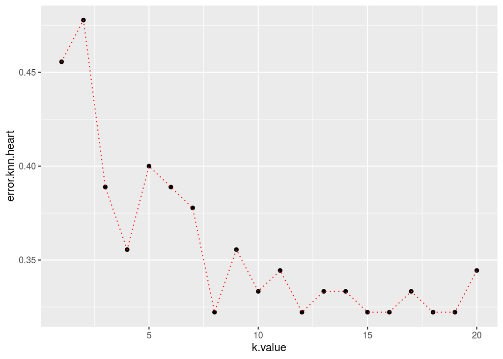

```r
k.value.df<-data.frame(k.value=1:20,error.knn.heart )
ggplot(k.value.df,aes(k.value,error.knn.heart ))+geom_point()+geom_line(lty='dotted',color='red')
```

```r
#KNN is not great for classification
```